# Practical 2

Hsuan Lee

# 1 Introduction

In this practical, we will perform singular value decomposition and perform principical component analysis. You will not have to load any packages in advance, as we will solely use base R. The data for todays practical can be downloaded here:

- `Example1.dat`

# 2 Take home exercises

## 2.1 SVD and Eigendecomposition

In this exercise, the data of Example 1 from the lecture slides are used. These data have been stored in the file Example1.dat.

**1. Use the function read.table() to import the data into R. Use the function as.matrix() to convert the data frame to a matrix. The two features are not centered. To center the two features the function scale() with the argument scale = FALSE can be used. Give the centered data matrix a name, for instance, C.**

```r
example <- read.table("data/Example1.dat")
example <- as.matrix(example)

# center the features
C <- scale(example, scale = F)
```

**2. Calculate the sample size N and the covariance matrix S by executing the following R code, where the function t() is used to calculate the transpose of C and %*% is used for matrix multiplication.**

```r
N <- dim(C)[1] # number of row of the matrix
S <- t(C) %*% C/N # covariance matrix
```

**3. Use the function svd() to apply a singular value decomposition to the centered data matrix.**

```r
SVD_center <- svd(C)
```

**4. Inspect the three pieces of output, that is, U, D, and V. Are the three matrices the same as on the slides?**

```r
SVD_center
```

```
## $d
## [1] 31.219745  5.032642
##
## $u
##              [,1]        [,2]
##  [1,] -0.26680000  0.28739123
##  [2,] -0.05470446 -0.33737580
##  [3,] -0.55896540 -0.13388431
##  [4,] -0.30683494 -0.23562992
##  [5,] -0.01466951  0.18564553
##  [6,]  0.19742603 -0.43912150
##  [7,]  0.48959143 -0.01784596
##  [8,]  0.02536542  0.70866669
##  [9,]  0.48959143 -0.01784596
##
## $v
##           [,1]       [,2]
## [1,] 0.4289437  0.9033312
## [2,] 0.9033312 -0.4289437
```

Yes, the obtained results are the same as slide 18.

**5. Use a single matrix product to calculate the principal component scores.**

```r
D <- diag(SVD_center$d)
U <- SVD_center$u

# principle component scores -> slide 19
PCscore <- U %*% D
PCscore
```

```
##              [,1]        [,2]
##  [1,]  -8.3294282  1.44633709
##  [2,]  -1.7078593 -1.69789153
##  [3,] -17.4507576 -0.67379177
##  [4,]  -9.5793087 -1.18584098
##  [5,]  -0.4579784  0.93428745
##  [6,]   6.1635905 -2.20994117
##  [7,]  15.2849198 -0.08981231
##  [8,]   0.7919021  3.56646553
##  [9,]  15.2849198 -0.08981231
```

**6. Plot the scores on the second principal component (y-axis) against the scores on the first principal component (x-axis) and let the range of the x-axis run from -18 to 18 and the range of the y-axis from -16 to 16.**

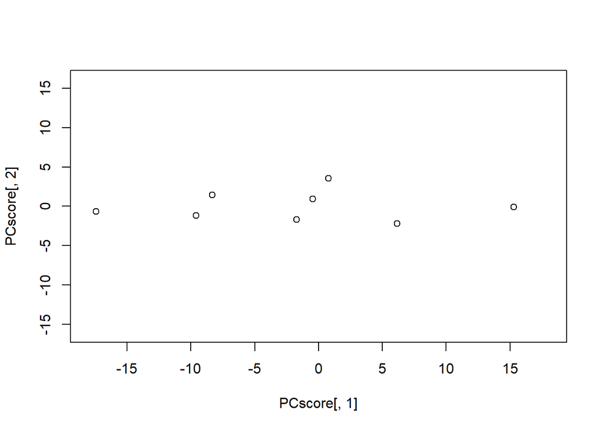

```r
plot(x = PCscore[,1], y = PCscore[,2], xlim = c(-18, 18), ylim = c(-16, 16))
```

**7. Use the function eigen() to apply an eigen-decomposition to the sample covariance matrix.**

```r
# slide 29, S -> sample covariance matrix
S_eigen_decomp <- (eigen(S))
S_eigen_decomp
```

```
## eigen() decomposition
## $values
## [1] 108.296945   2.814165
##
## $vectors
##           [,1]       [,2]
## [1,] 0.4289437 -0.9033312
## [2,] 0.9033312  0.4289437
```

**8. Check whether the eigenvalues are equal to the variances of the two principal components. Be aware that the R-base function var() takes N−1 in the denominator, to get an unbiased estimate of the variance.**

```r
# variance formula -> slide 8
options(scipen = 999)
t(PCscore) %*% PCscore / N
```

```
##                            [,1]                      [,2]
## [1,] 108.2969446662856825014387 -0.0000000000000004934325
## [2,]  -0.0000000000000004934325  2.8141647439907755412491
```

Yes, they are the same.

**9. Finally, calculate the percentage of total variance explained by each principal component.**

```r
# slide 33
S_eigen_decomp$values/sum(S_eigen_decomp$values)*100
```

```
## [1] 97.467252  2.532748
```

## 2.2 Principal component analysis

In this exercise, a PCA is used to determine the financial strength of insurance companies. Eight relevant features have been selected: (1) gross written premium, (2) net mathematical reserves, (3) gross claims paid, (4) net premium reserves, (5) net claim reserves, (6) net income, (7) share capital, and (8) gross written premium ceded in reinsurance.

To perform a principal component analysis, an eigendecomposition can be applied to the sample correlation matrix R instead of the sample covariance matrix S. Note that the sample correlation matrix is the sample covariance matrix of the standardized features. These two ways of doing a PCA will yield different results. If the features have the same scales (the same units), then the covariance matrix should be used. If the features have different scales, then it’s better in general to use the correlation matrix because otherwise the features with high absolute variances will dominate the results.

Based on the correlation table, the correlation excel sheet was created by myself.

```r
library(tidyverse)
correlation <- read.csv("data/Correlation.csv") %>%
  select(-1) %>%
  as.matrix()
```

**9. Use R to apply a PCA to the sample correlation matrix.**

An alternative criterion for extracting a smaller number of principal components m than the number of original variables p in applying a PCA to the sample correlation matrix, is the eigenvalue-greater-than-one rule. This rule says that m (the number of extracted principal components) should be equal to the number of eigenvalues greater than one. Since each of the standardized variables has a variance of one, the total variance is p. If a principal component has an eigenvalue greater than one, than its variance is greater than the variance of each of the original standardized variables. Then, this principal component explains more of the total variance than each of the original standardized variables.

```r
# slide 38
R_eigen_decomp <- eigen(correlation)
R_eigen_decomp
```

```
## eigen() decomposition
## $values
## [1] 4.654827640 1.446030987 1.014432893 0.571991390 0.252849855 0.030896265
## [7] 0.024937666 0.004033303
##
## $vectors
##             [,1]        [,2]        [,3]        [,4]        [,5]        [,6]
## [1,] -0.45570531  0.12463861  0.02088898  0.09143931  0.08670416  0.15624367
## [2,] -0.08689900  0.52463760  0.64691821  0.49402517  0.09829888  0.03301796
## [3,] -0.45188484 -0.01953857 -0.15139278 -0.02028604 -0.15374784  0.77321029
## [4,] -0.44624499  0.04180405  0.03735239 -0.05121431 -0.45226743 -0.50350707
## [5,] -0.42053982 -0.29072335  0.03373389  0.15985973 -0.30317044 -0.21447390
## [6,] -0.05961452  0.72505439 -0.16605510 -0.57393946 -0.13338165 -0.05338675
## [7,] -0.25148835 -0.29178379  0.57778034 -0.59904953  0.39039893 -0.01771592
## [8,] -0.37120442  0.10830307 -0.44068482  0.17527574  0.70179853 -0.27195800
##              [,7]        [,8]
## [1,]  0.038874157  0.85706447
## [2,] -0.043269517 -0.20497515
## [3,]  0.136731994 -0.36317881
## [4,]  0.566496879 -0.12694808
## [5,] -0.751619348 -0.09534185
## [6,] -0.303156525 -0.03488190
## [7,]  0.009592252 -0.07815482
## [8,]  0.008640717 -0.24289099
```

**10. How many principal components should be extracted according to the eigenvalue-greater-than-one rule?**

```r
R_eigen_decomp$values[which(R_eigen_decomp$values > 1)]
```

```
## [1] 4.654828 1.446031 1.014433
```

Three principle components should be extracted.

**11. How much of the total variance does this number of extracted principal components explain?**

```r
sum(R_eigen_decomp$values[1:3])/sum(R_eigen_decomp$values)*100
```

```
## [1] 88.94114
```

89% total variance can be explained by these three principle components.

**12. Make a scree-plot. How many principal components should be extracted according to the scree-plot?**

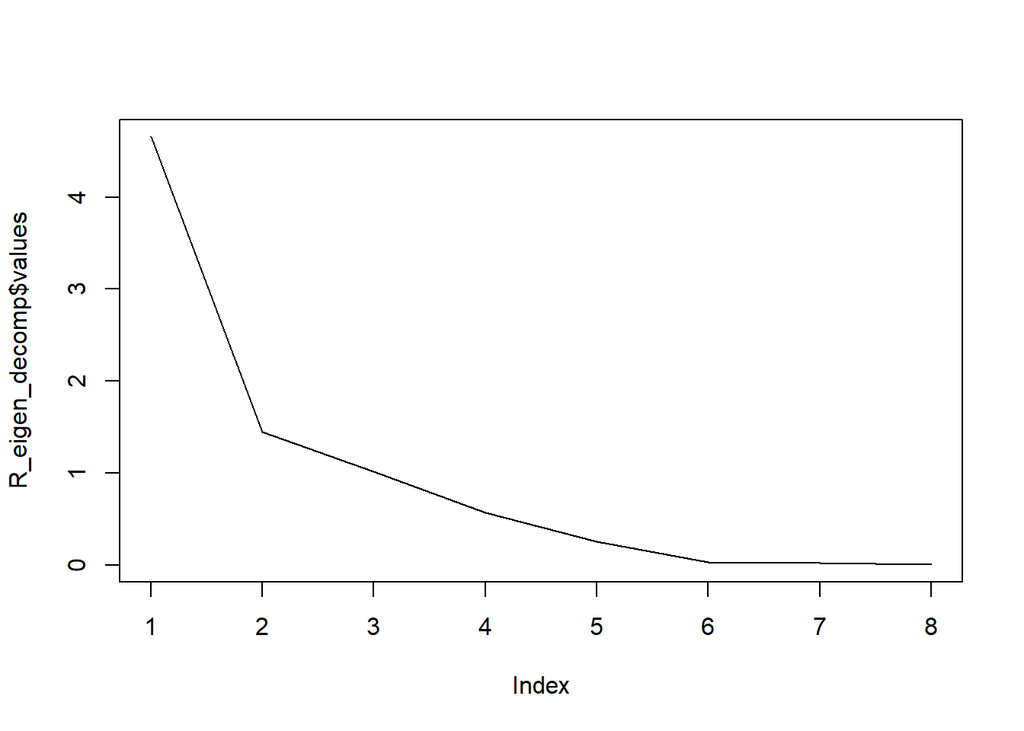

```r
# slide 41, x axis is eigenvalue
plot(R_eigen_decomp$values, type = "l")
```

**13. How much of the total variance does this number of extracted principal components explain?**

```r
# slide 40
# for the first principle component
sum(R_eigen_decomp$values[1])/sum(R_eigen_decomp$values)*100
```

```
## [1] 58.18535
```

```r
# for the second principle component
sum(R_eigen_decomp$values[1:2])/sum(R_eigen_decomp$values)*100
```

```
## [1] 76.26073
```

```r
# for the third principle component
sum(R_eigen_decomp$values[1:3])/sum(R_eigen_decomp$values)*100
```

```
## [1] 88.94114
```

The cumulative percentage of the variance explained(CPVE) can be seen from the output.

# Lab exercise

In this assignment, you will perform a PCA to a simple and easy to understand dataset. You will use the mtcars dataset, which is built into R. This dataset consists of data on 32 models of car, taken from an American motoring magazine (1974 Motor Trend magazine). For each car, you have 11 features, expressed in varying units (US units). They are as follows:

- mpg: fuel consumption (miles per (US) gallon); more powerful and heavier cars tend to consume more fuel.
- cyl: number of cylinders; more powerful cars often have more cylinders.
- disp: displacement (cu.in.); the combined volume of the engine’s cylinders.
- hp: gross horsepower; this is a measure of the power generated by the car.
- drat: rear axle ratio; this describes how a turn of the drive shaft corresponds to a turn of the wheels. Higher values will decrease fuel efficiency.
- wt: weight (1000 lbs).
- qsec: 1/4 mile time, the cars speed and acceleration.
- vs: engine block; this denotes whether the vehicle’s engine is shaped like a ‘V’, or is a more common straight shape.
- am: transmission; this denotes whether the car’s transmission is automatic (0) or manual (1).
- gear: number of forward gears; sports cars tend to have more gears.
- carb: number of carburetors; associated with more powerful engines.

Note that the units used vary and occupy different scales.

First, the principal components will be computed. Because PCA works best with numerical data, you’ll exclude the two categorical variables (vs and am; columns 8 and 9). You are left with a matrix of 9 columns and 32 rows, which you pass to the prcomp() function, assigning your output to mtcars.pca. You will also set two arguments, center and scale, to be TRUE. This is done to apply a principal component analysis to the standardized features. So, execute

```r
mtcars.pca <- prcomp(mtcars[, c(1:7, 10, 11)],
                     center = TRUE,
                     scale = TRUE)
```

**14. Have a peek at the PCA object with summary().**

```r
summary_mtcars.pca <- summary(mtcars.pca)
summary_mtcars.pca
```

```
## Importance of components:
##                           PC1    PC2     PC3     PC4     PC5     PC6     PC7
## Standard deviation     2.3782 1.4429 0.71008 0.51481 0.42797 0.35184 0.32413
## Proportion of Variance 0.6284 0.2313 0.05602 0.02945 0.02035 0.01375 0.01167
## Cumulative Proportion  0.6284 0.8598 0.91581 0.94525 0.96560 0.97936 0.99103
##                           PC8     PC9
## Standard deviation     0.2419 0.14896
## Proportion of Variance 0.0065 0.00247
## Cumulative Proportion  0.9975 1.00000
```

You obtain 9 principal components, which you call PC1-9. Each of these explains a percentage of the total variance in the dataset.

**15. What is the percentage of total variance explained by PC1?**

From the output of summary function, we can see the total variance explained by PC1 is 0.6284.

**16. What is the percentage of total variance explained by PC1, PC2, and PC3 together?**

```r
summary_mtcars.pca[["importance"]][3,3]
```

```
## [1] 0.91581
```

The total variance explained by PC1, PC2, and PC3 together is 0.92.

The PCA object mtcars.pca contains the following information:

- the center point or the vector of feature means ($center)
- the vector of feature standard deviations ($scale)
- the vector of standard deviations of the principal components ($sdev)
- the eigenvectors ($rotation)
- the principal component scores ($x)

**16. Determine the eigenvalues. How many principal components should be extracted according to the eigenvalue-greater-than-one rule?**

```r
# slide 29, eigenvalue is exactly the same as the variance of principle components
(summary_mtcars.pca$sdev)^2
```

```
## [1] 5.65593947 2.08210029 0.50421482 0.26502753 0.18315864 0.12379319 0.10506192
## [8] 0.05851375 0.02219038
```

**17. What is the value of the total variance? Why?**

```r
# slide 9
sum((summary_mtcars.pca$sdev)^2)
```

```
## [1] 9
```

The total variance is 9. The total variance is defined as the trace of covariance matrix or correlation matrix, so we should sum the variances of the number of variables.

**18. How much of the total variance is explained by the number of extracted principal components according to the eigenvalue-greater-than-one rule?**

```r
summary_mtcars.pca[["importance"]][3,2]
```

```
## [1] 0.85978
```

86% of the total variance is explained by the first two of extracted principal components.

Next, a couple of plots will be produced to visualize the PCA solution. You will make a biplot, which includes both the position of each observation (car model) in terms of PC1 and PC2 and also will show you how the initial features map onto this. A biplot is a type of plot that will allow you to visualize how the observations relate to one another in the PCA (which observations are similar and which are different) and will simultaneously reveal how each feature contributes to each principal component.

**19. Use the function biplot() with the argument choices = c(1, 2) to ask for a biplot for the first two principal components.**

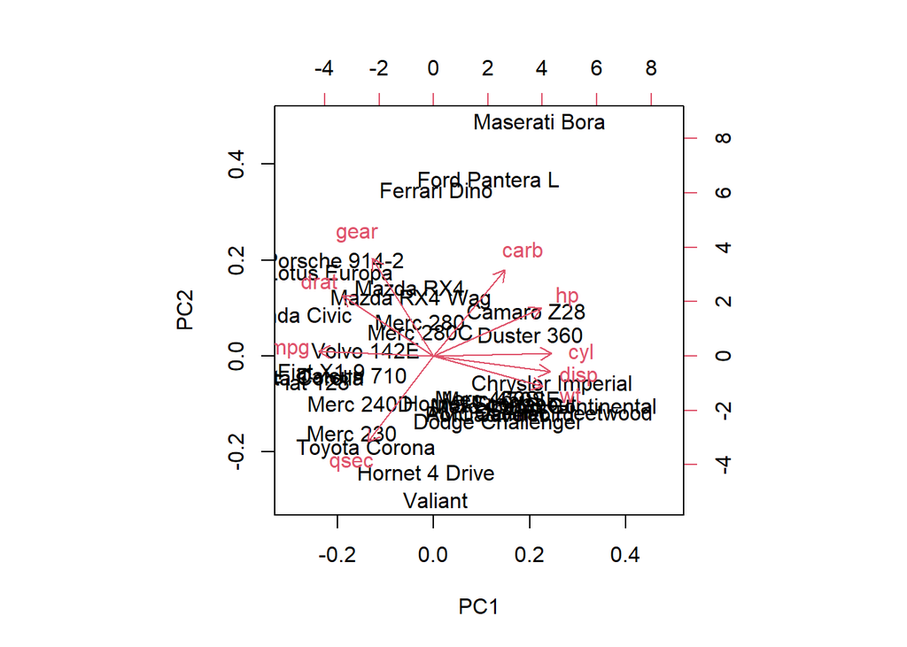

```r
biplot(mtcars.pca, choices = c(1,2))
```

The axes of the biplot are seen as arrows originating from the center point. Here, you see that the variables hp, cyl, and disp all contribute to PC1, with higher values in those variables moving the observations to the right on this plot. This lets you see how the car models relate to the axes. You can also see which cars are similar to one another. For example, the Maserati Bora, Ferrari Dino and Ford Pantera L all cluster together at the top. This makes sense, as all of these are sports cars.

**20. Make a biplot for the first and third principal components. Especially which brand of car has negative values on the first principal component and positive values on the third principal component?**

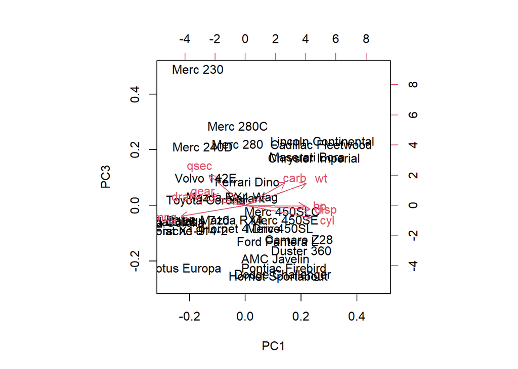

```r
biplot(mtcars.pca, choices = c(1,3))
```

Volvo, Toyota,etc., have negative values in the first principle component; Merc possess positive values in the third principle component.

**21. Use the function screeplot() with the argument type = ‘lines’ to produce a scree-plot. How many principal components should be extracted according to this plot? Why? Is this number in agreement with the number of principal components extracted according to the eigenvalue-greater-than-one rule?**

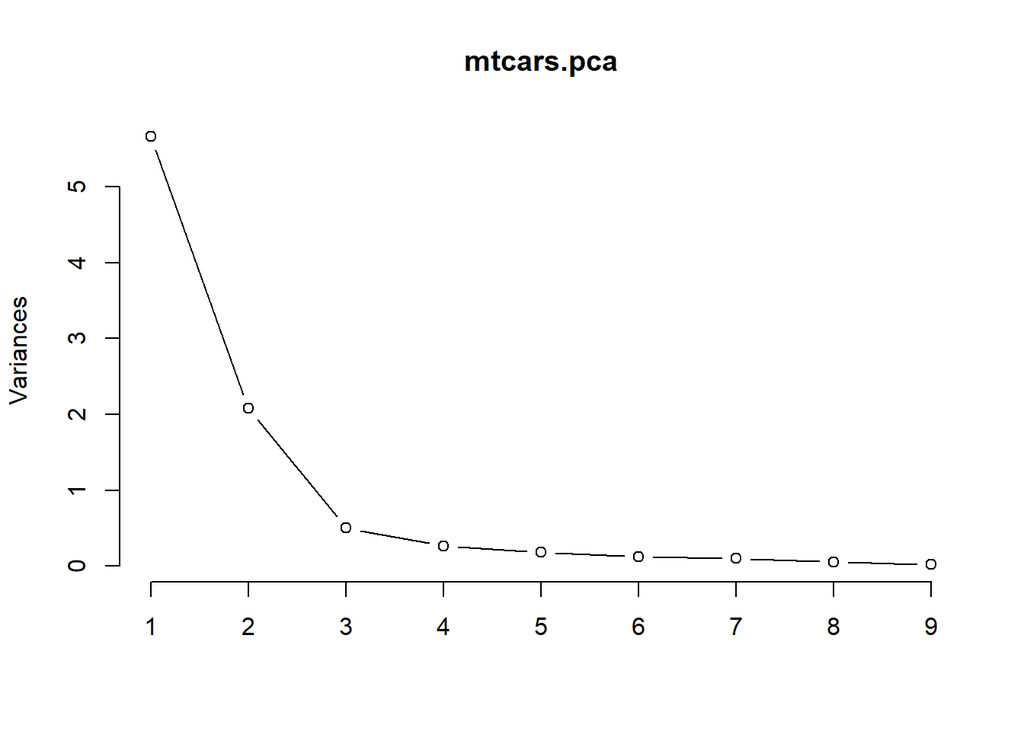

```r
# slide 41
screeplot(mtcars.pca, type = "l")
```

The number of principal components to be extracted is equal to the number of eigenvalues greater than the elbow in the scree plot. The elbow is shown at three in this plot, so two principle components should be extracted, which is the same suggestion given by eigenvalue-greater-than-one rule.